# Project Workspace

Energyyy

```r
library(knitr)
knitr::opts_chunk$set(message = FALSE, warning = FALSE)
```

```r
library(tidyverse)
library(broom)
library(tidyr)
library(readxl)
#install.packages("leaflet")
library(leaflet)
#install.packages("sf")
library(sf)
#install.packages("gganimate")
library(gganimate)
library(ggthemes)
library(gapminder)
```

```r
table_Residential <- read_excel("/cloud/project/data/table_Residential.xlsx",
                                na = c("."))
table_Commercial <- read_excel("/cloud/project/data/table_Commercial.xlsx",
                               na = c("."))
table_Industrial <- read_excel("/cloud/project/data/table_Industrial.xlsx",
                               na = c("."))
table_Transportation <- read_excel("/cloud/project/data/table_Transportation.xlsx",
                                   na = c("."))
table_Disturbance <- read_excel("/cloud/project/data/table_Disturbance.xlsx",
                                na= c(".", ". Hours,  . Minutes", "Unknow", ".        ."))
table_CAIDI <- read_excel("/cloud/project/data/table_CAIDI.xlsx")

USA_df <- sf::st_read("/cloud/project/data/USA_States_Generalized.shp")
```

This mutate function adds a column which contains the sector of the data.

```r
USA_df <- USA_df %>%
 rename(`Census Division\r\nand State` = STATE_NAME)
residential <- table_Residential %>%
  mutate(Sector = c("Residential"))
commercial <- table_Commercial %>%
  mutate(Sector = c("Commercial"))
transportation <- table_Transportation %>%
  mutate(Sector = c("Transportation"))
industrial <- table_Industrial %>%
  mutate(Sector = c("Industrial"))
```

This code binds all the tables with sectors together.

```r
energy_sector <- bind_rows(residential, commercial, industrial, transportation)
```

```r
table_Disturbance <- table_Disturbance |>
  mutate(Entity = `Utility/Power Pool`)

energy_sector_rev_sum <- energy_sector |>
  select(Entity, Ownership, `Revenues (Thousands Dollars)`) |>
  group_by(Entity, Ownership) |>
  summarise(sum_revenue = sum(`Revenues (Thousands Dollars)`)) |>
  as.data.frame()
```

```r
table_CAIDI <- table_CAIDI |>
 pivot_longer(cols = `2013`:`2022`,
              names_to = "Year",
              values_to = "CAIDI")
```

```r
our_theme <- theme_grey() +
  theme(text = element_text(color = "#1d91c0"),
        legend.text = element_text(color = "black"))
```

## 1. Ownership vs price of electricity /according to sector

- Q: Does ownership e.g. cooperatives influence the average price of electricity, does it benefit individuals/residential sector or is it more geared towards commercial sector…?`

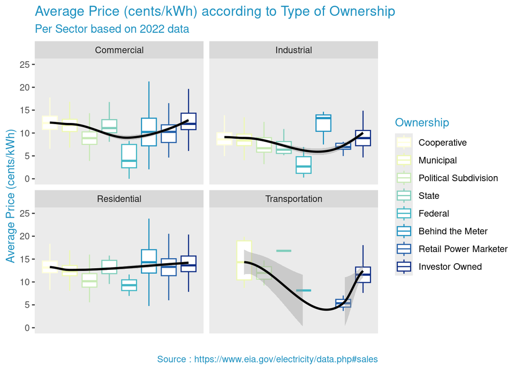

```r
energy_sector |>
  filter(!is.na(Ownership)) |>
  mutate(
    Ownership = fct_relevel(
      Ownership,
      "Cooperative", "Municipal", "Political Subdivision", "State", "Federal", "Behind the Meter", "Retail Power Marketer", "Investor Owned"
    )) |>

 ggplot(aes(x = as.numeric(Ownership), y = `Average Price (cents/kWh)`)) +
  geom_boxplot(outlier.shape = NA, aes(color = Ownership)) +
  geom_smooth(method = "loess", color = "black") +
  ylim(0,25)+
  facet_wrap(~Sector) +
  scale_color_manual(values = c("Cooperative" = "#ffffd9", "Municipal" = "#edf8b1", "Political Subdivision" = "#c7e9b4", "State" = "#7fcdbb", "Federal" = "#41b6c4", "Behind the Meter" = "#1d91c0", "Retail Power Marketer" = "#225ea8", "Investor Owned" = "#0c2c84")) +
  labs(
    title = "Average Price (cents/kWh) according to Type of Ownership",
    subtitle = "Per Sector based on 2022 data",
    caption = "Source : https://www.eia.gov/electricity/data.php#sales",
    x = "") +
  our_theme +
  theme(axis.text.x = element_blank(),
        axis.ticks.x = element_blank(),
        panel.grid = element_blank())
```

```r
#ggsave(filename = "Ownership vs price.png", device = "png")
```

# 2a. Revenue and actual blackouts and ownership

- Q: does less profit and community owned mean less blackouts? Or does ownership tell us that big companies have more means to prevent blackouts?

```r
disturbance_count <- table_Disturbance |>
  group_by(Entity) |>
  count()

disturbance_complete <- disturbance_count |>
  inner_join(energy_sector_rev_sum)
```

For the next plot we want to count the disturbances per utility company.

[figure not shown]

```r
ggplot(disturbance_complete, aes(
  y = sum_revenue/1000000,
  x = `Ownership`,
  size = n)) +
  geom_point(color = "#1d91c0", alpha = 0.8) +
  labs(title = "Number of Disturbances per Utility Company",
       subtitle = "in relation to Ownership Type and Revenue",
       x = "Type of Ownership", y = "Revenue in Million Dollars ($)",
       size = "Number of\nDisturbances",
       caption = "Source : https://www.eia.gov/electricity/data.php#sales") +
  our_theme
```

# 2b. CAIDI reliability in electricity networks throughout the US based on states

```r
# Create a base plot
CAIDI_leaflet_df$Year <-as.numeric(CAIDI_leaflet_df$Year)

p <- CAIDI_leaflet_df |>
  ggplot(aes(fill = CAIDI,
             group = Year)) +
  geom_sf() +
  xlim(125, 68) +
  ylim(24.5, 50) +
  scale_fill_viridis_c() +
  our_theme +
  theme(axis.text.x = element_blank(),
        axis.ticks.x = element_blank(),
        axis.text.y = element_blank(),
        axis.ticks.y = element_blank(),
        panel.grid = element_blank(),
        panel.background = element_rect(fill='white')) +
  labs(title = "Customer Average Interruption Duration Index (CAIDI) map of lower 48 US states",
       subtitle = "Year: {closest_state}",
       caption = "Source: https://www.eia.gov/electricity/data/annual/")

# Create an animated plot
p <- p + transition_states(
  states = Year,
  transition_length = 3,
  state_length = 3)

#animate(p, duration = 30, renderer = gifski_renderer("map.gif"))
```

## 3. Amount of electricity used, cheaper prices?

- Q: Is it cheaper to buy electricity depending on the sector? Is buying electricity in bulk cheaper?
- compare this to experience in history: companies that consume lots of electricity usually get cheaper electricity prices because utilities had reliable demand from the industries
- electricity producers want reliable consumers –> does this bias still exist? Book: “The Grid”

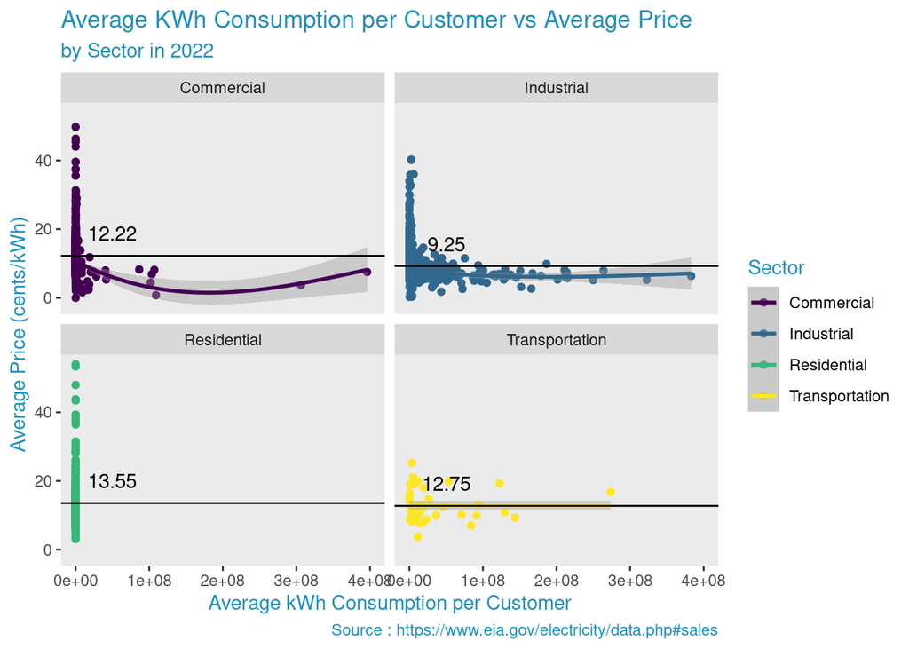

```r
#creating the mean of average price in each sector
line_test <- energy_sector |>
  summarise(mean(`Average Price (cents/kWh)`, na.rm = TRUE),.by = Sector)

line_test$mean <- line_test$`mean(\`Average Price (cents/kWh)\`, na.rm = TRUE)`

line_test$label <-
  round(line_test$mean, 2)

#create graph using mean of average price in each sector
energy_sector |>
  ggplot(aes(x = (
    `Sales (Megawatthours)`*1000/`Customers (Count)`), y = `Average Price (cents/kWh)`, color = Sector)) +
  geom_point() +
  geom_smooth() +
  geom_hline(data = line_test, aes(yintercept = mean)) +
  geom_text(data = line_test, aes(50000000, y = label, label = label, vjust = -1), color = "black") +
  facet_wrap(~Sector) +
  scale_color_viridis_d() +
  xlim(0, 400000000) +
  labs(
    title = "Average KWh Consumption per Customer vs Average Price",
    subtitle = "by Sector in 2022",
    x = "Average kWh Consumption per Customer",
    y = "Average Price (cents/kWh)",
    caption = "Source : https://www.eia.gov/electricity/data.php#sales"
  ) +
  our_theme +
  theme(panel.grid = element_blank())
```

## [4. Number of customers vs price by sector – if we are bored, we can do this!

- Q: Do bigger utility companies (meaning more customers) offer lower avg. prices due to scale?

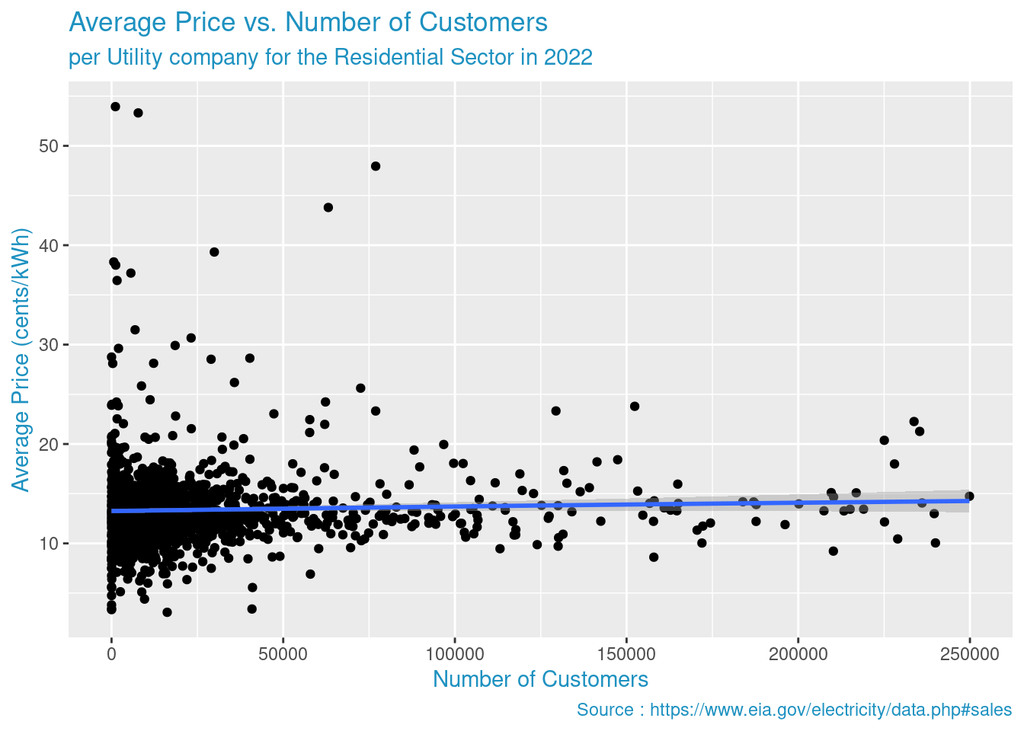

```r
energy_sector |>
  filter(Sector == "Residential") |>
  ggplot(aes(x = `Customers (Count)`, y = `Average Price (cents/kWh)`)) +
  geom_point() +
  geom_smooth() +
  xlim(0, 250000) +
  labs(title = "Average Price vs. Number of Customers",
       subtitle = "per Utility company for the Residential Sector in 2022",
       x = "Number of Customers",
       y = "Average Price (cents/kWh)",
       caption = "Source : https://www.eia.gov/electricity/data.php#sales") +
  our_theme
```

## 5. Per household consumption of electricity (megawatthours sold/customers) vs price

- Q: Do consumers use less electricity if it is more expensive?

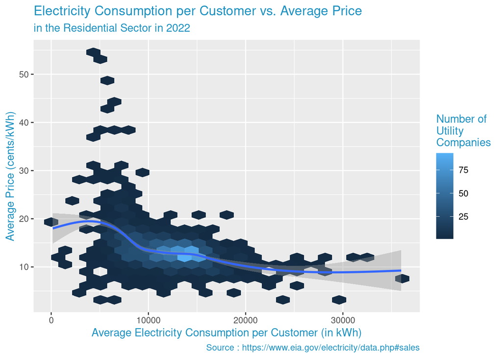

```r
ggplot(table_Residential, aes(x = (`Sales (Megawatthours)`*1000)/`Customers (Count)`, y = `Average Price (cents/kWh)`)) +
  geom_hex() +
  geom_smooth() +
  labs(title = "Electricity Consumption per Customer vs. Average Price",
       subtitle = "in the Residential Sector in 2022",
       x = "Average Electricity Consumption per Customer (in kWh)",
       y = "Average Price (cents/kWh)",
       fill = "Number of\nUtility\nCompanies",
       caption = "Source : https://www.eia.gov/electricity/data.php#sales") +
  our_theme
```